# STATS 32: Introduction to R for Undergraduates

Elena Tuzhilina

Oct 21, 2021  
http://web.stanford.edu/~elenatuz/courses/stats32-aut2021/

# Announcements

Project due on **30 Oct (Sat) 11:59pm**

Remaining office hours (Zoom)

- 22 Oct (tomorrow)
- 29 Oct (next Friday)

# Recap of session 9

- Joining datasets with `left_join`
  - `df1 %>% left_join(df2, by = "key")`
- Making maps in R
  - `geom_polygon()`
  - `aes(x = long, y = lat, group = group)`

# Agenda for today

- A crash course in statistics and modeling
  - Hypothesis testing
  - Linear regression

A very high level picture: for technical details, take STATS 60/STATS 101

# Hypothesis test

`mpg`: miles per gallon

`am`: transmission (0 = automatic, 1 = manual)

|  | mpg | cyl | disp | hp | drat | wt | qsec | vs | am | gear | carb |
| --- | --- | --- | --- | --- | --- | --- | --- | --- | --- | --- | --- |
| Mazda RX4 | 21.0 | 6 | 160 | 110 | 3.90 | 2.620 | 16.46 | 0 | 1 | 4 | 4 |
| Mazda RX4 Wag | 21.0 | 6 | 160 | 110 | 3.90 | 2.875 | 17.02 | 0 | 1 | 4 | 4 |
| Datsun 710 | 22.8 | 4 | 108 | 93 | 3.85 | 2.320 | 18.61 | 1 | 1 | 4 | 1 |
| Hornet 4 Drive | 21.4 | 6 | 258 | 110 | 3.08 | 3.215 | 19.44 | 1 | 0 | 3 | 1 |
| Hornet Sportabout | 18.7 | 8 | 360 | 175 | 3.15 | 3.440 | 17.02 | 0 | 0 | 3 | 2 |
| Valiant | 18.1 | 6 | 225 | 105 | 2.76 | 3.460 | 20.22 | 1 | 0 | 3 | 1 |

**Is it true that cars with manual transmission consume the same amount of gas as automatic?**

# Hypothesis test

```r
library(dplyr)
df <- mtcars %>%
    select(mpg, am) %>%
    rename(miles_per_gallon = mpg, transmission = am) %>%
    mutate(transmission = ifelse(transmission == 0, "automatic", "manual"))
```

|  | miles_per_gallon | transmission |
| --- | --- | --- |
| Mazda RX4 | 21.0 | manual |
| Mazda RX4 Wag | 21.0 | manual |
| Datsun 710 | 22.8 | manual |
| Hornet 4 Drive | 21.4 | automatic |
| Hornet Sportabout | 18.7 | automatic |
| Valiant | 18.1 | automatic |

# Hypothesis test

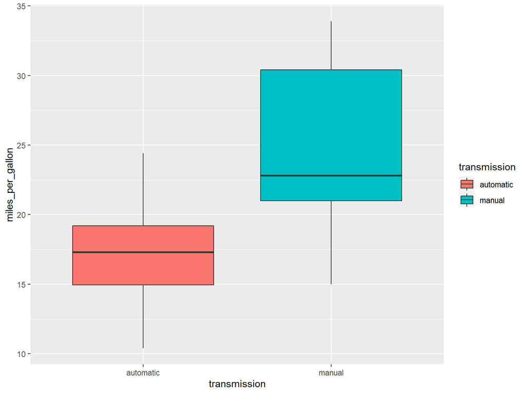

```r
library(ggplot2)
ggplot(data = df)+
    geom_boxplot(aes(x = transmission, y = miles_per_gallon,
                     fill = transmission))
```

# Hypothesis test

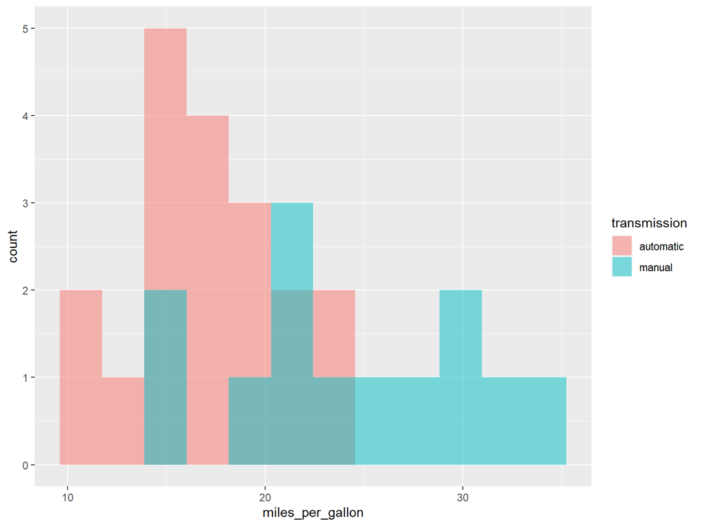

```r
ggplot(data = df)+
    geom_histogram(aes(x = miles_per_gallon, fill = transmission),
                   bins = 12, alpha = 0.5, position="identity")
```

# Hypothesis test

```r
df %>%
    group_by(transmission) %>%
    summarize(mean_mpg = mean(miles_per_gallon))
```

```
## # A tibble: 2 x 2
##   transmission mean_mpg
##   <chr>           <dbl>
## 1 automatic        17.1
## 2 manual           24.4
```

**How significant is this difference?**

# Structure of a hypothesis test

1. Start with a **null hypothesis**: An assumption on how the data is generated

# Structure of a hypothesis test

1. Start with a **null hypothesis**: An assumption on how the data is generated
2. Based on this assumption, how likely were we to collect data as extreme as what we have?
   - **p-value**: probability of collecting data as extreme as ours (if null hypothesis is true)

# Structure of a hypothesis test

1. Start with a **null hypothesis**: An assumption on how the data is generated
2. Based on this assumption, how likely were we to collect data as extreme as what we have?
   - **p-value**: probability of collecting data as extreme as ours (if null hypothesis is true)
3. Is the p-value considered low or not?
   - Threshold should depend on the context
   - Typical threshold is 0.05 (there is a 5% chance of making a mistake)

# Structure of a hypothesis test

1. Start with a **null hypothesis**: An assumption on how the data is generated
2. Based on this assumption, how likely were we to collect data as extreme as what we have?
   - **p-value**: probability of collecting data as extreme as ours (if null hypothesis is true)
3. Is the p-value considered low or not?
   - Threshold should depend on the context
   - Typical threshold is 0.05 (there is a 5% chance of making a mistake)
4. If p-value is below threshold, 2 possible conclusions:
   - A rare event just happened, or
   - Our assumption in Step 1 was false

# Hypothesis test: `mtcars` example

# Hypothesis test: `mtcars` example

**Is it true that cars with manual transmission consume the same amount of gas as automatic?**

1. Start with a **null hypothesis**: average `mpg` for automatic transmission is **equal to** the one for manual transmission

`mean(mpg for manual) = mean(mpg for automatic)`

# Hypothesis test: `mtcars` example

**Is it true that cars with manual transmission consume the same amount of gas as automatic?**

2. Based on this assumption, how likely were we to collect data as extreme as what we have?

The histogram looks suspicious. The difference is high

`mean(mpg for manual) - mean(mpg for automatic) = 24.4 - 17.2 = 7.2`

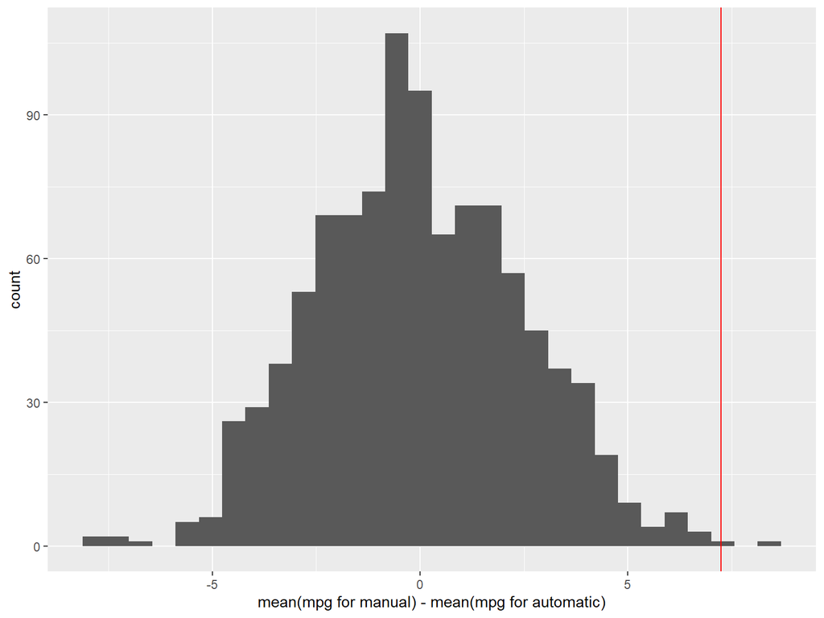

**p-value**: probability of collecting data as extreme as ours (if null hypothesis is true)

```
## p-value =  0.001374
```

# Hypothesis test: `mtcars` example

**Is it true that cars with manual transmission consume the same amount of gas as automatic?**

3. Is the p-value considered low or not?
   - compare our p-value to the threshold 0.001374 < 0.05

# Hypothesis test: `mtcars` example

**Is it true that cars with manual transmission consume the same amount of gas as automatic?**

4. p-value is below threshold, 2 possible conclusions:
   - A rare event just happened, or
   - Our assumption in Step 1 was false

We reject H0.

**It is NOT true that**

`mean(mpg for manual) = mean(mpg for automatic)`

**It is NOT true that**

cars with automatic transmission consume the same amount of gas as manual.

**We are 95% sure!**

# How to get p-value: t-test

**Is it true that cars with manual transmission consume the same amount of gas as automatic?**

Good part: R will do all the computations for you.

**Null hypothesis**: mean mpg for automatic transmission is the same as mean mpg for manual

```r
df_manual <- df %>% filter(transmission == "manual")
head(df_manual)
```

```
##                miles_per_gallon transmission
## Mazda RX4                  21.0       manual
## Mazda RX4 Wag              21.0       manual
## Datsun 710                 22.8       manual
## Fiat 128                   32.4       manual
## Honda Civic                30.4       manual
## Toyota Corolla             33.9       manual
```

```r
df_automatic <- df %>% filter(transmission == "automatic")
head(df_automatic)
```

```
##                   miles_per_gallon transmission
## Hornet 4 Drive                21.4    automatic
## Hornet Sportabout             18.7    automatic
## Valiant                       18.1    automatic
## Duster 360                    14.3    automatic
## Merc 240D                     24.4    automatic
## Merc 230                      22.8    automatic
```

# How to get p-value: t-test

**Is it true that cars with manual transmission consume the same amount of gas as automatic?**

Good part: R will do all the computations for you.

**Null hypothesis**: mean mpg for automatic transmission is the same as mean mpg for manual

```r
mpg_manual <- df_manual$miles_per_gallon
mpg_manual
```

```
##  [1] 21.0 21.0 22.8 32.4 30.4 33.9 27.3 26.0 30.4 15.8 19.7 15.0 21.4
```

```r
mpg_automatic <- df_automatic$miles_per_gallon
mpg_automatic
```

```
##  [1] 21.4 18.7 18.1 14.3 24.4 22.8 19.2 17.8 16.4 17.3 15.2 10.4 10.4 14.7 21.5
## [16] 15.5 15.2 13.3 19.2
```

# How to get p-value: t-test

**Is it true that cars with manual transmission consume the same amount of gas as automatic?**

Good part: R will do all the computations for you.

**Null hypothesis**: mean mpg for automatic transmission is the same as mean mpg for manual

```r
t.test(mpg_manual, mpg_automatic)
```

```
##
##  Welch Two Sample t-test
##
## data:  mpg_manual and mpg_automatic
## t = 3.7671, df = 18.332, p-value = 0.001374
## alternative hypothesis: true difference in means is not equal to 0
## 95 percent confidence interval:
##   3.209684 11.280194
## sample estimates:
## mean of x mean of y
##  24.39231  17.14737
```

# What is a model?

Pearson-Lee data.

| parent | child | par | chl |
| --- | --- | --- | --- |
| 62.5 | 59.5 | Father | Son |
| 63.5 | 59.5 | Father | Son |
| 64.5 | 59.5 | Father | Son |
| 62.5 | 60.5 | Father | Son |
| 66.5 | 60.5 | Father | Son |
| 59.5 | 61.5 | Father | Son |

**Want to model the dependence between parent’s and child’s height.**

# What is a model?

Pearson-Lee data.

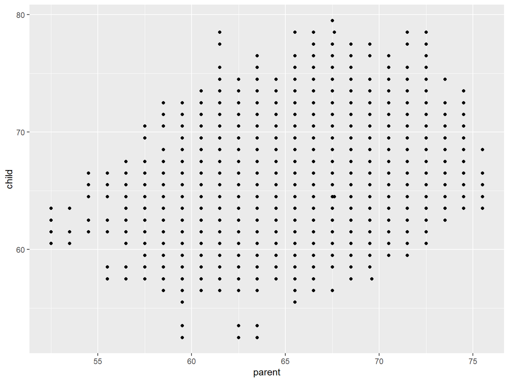

```r
ggplot(data = df, aes(x = parent, y = child)) +
    geom_point()
```

**Want to model the dependence between parent’s and child’s height.**

# What is a model?

A **model** is a simplified and idealized way to understand your data.

**Linear model**: $child = a + b \cdot parent$.

**Model (unknown) parameters**:

- $a$ is intercept
- $b$ is slope

Many other possible models: linear without intercept, quadratic, exponential, …

# Different models within the linear model family

Each line corresponds to a choice of $a$ and $b$.

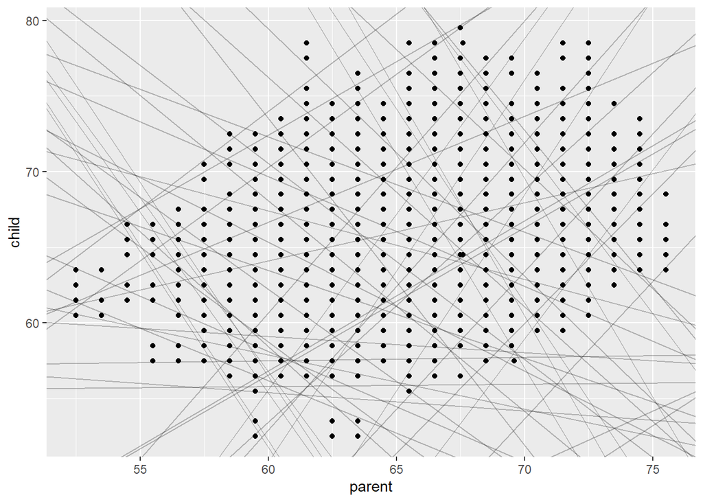

# Different models within the linear model family

**What values of $a$ and $b$ are the best?**

Which make the model match the data “most closely”.

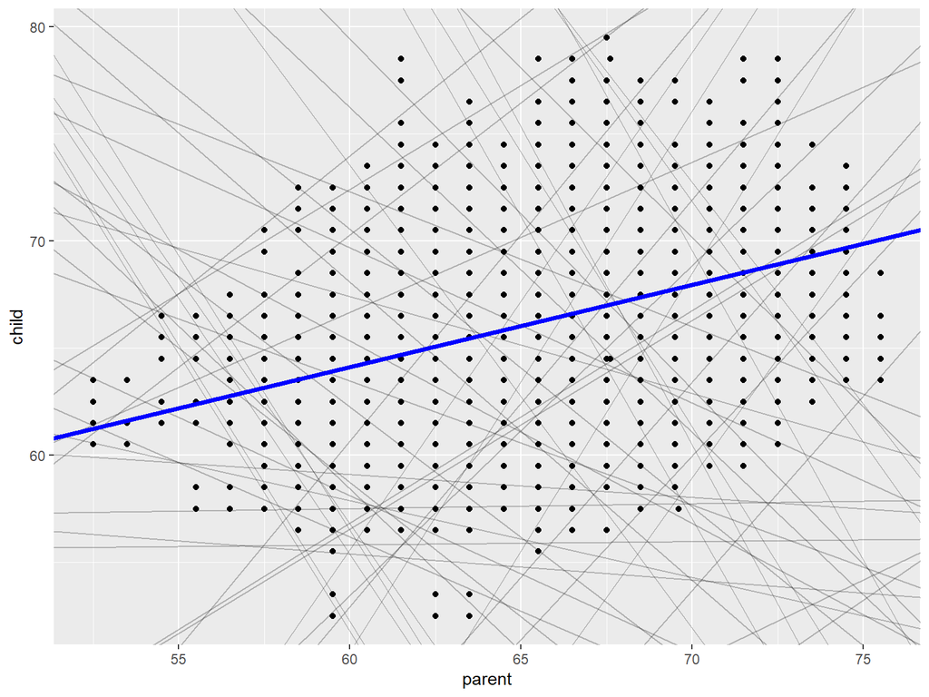

# What do we mean by “closely matching the data”?

We choose $a$ and $b$ such that minimize the sum of squares of the black lines below.

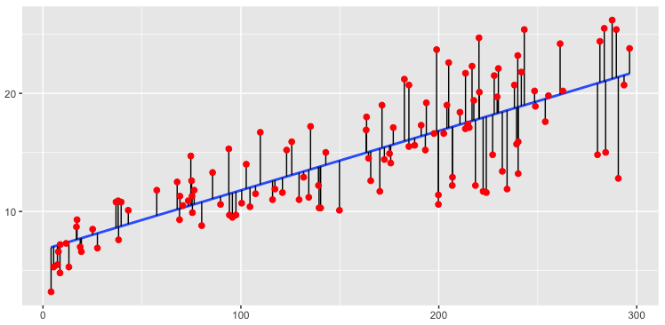

(Source: [uc-r.github.io](http://uc-r.github.io/linear_regression))

# Linear models in R

- Linear regression can be done with the `lm` function
- Syntax: `lm(formula, data = df)`
- Formulas look like `y ~ x`, which `lm` will translate to a function like $y = a + b \cdot x$

```r
lm(child ~ parent, data = df)
```

```
##
## Call:
## lm(formula = child ~ parent, data = df)
##
## Coefficients:
## (Intercept)       parent
##     41.0691       0.3842
```

# Linear models in R

```r
lm(child ~ parent, data = df)
```

```
##
## Call:
## lm(formula = child ~ parent, data = df)
##
## Coefficients:
## (Intercept)       parent
##     41.0691       0.3842
```

- $a = 41.0691$ is intercept
- $b = 0.3842$ is slope

**Model:** $child = 41.0691 + 0.3842 \cdot parent$

**Interpretation:** if parent’s height increases by one unit, the child gets higher by $0.3842$ units.

# Linear models in R

```r
fit <- lm(child ~ parent, data = df)
coef(fit)
```

```
## (Intercept)      parent
##   41.069105    0.384221
```

```r
a <- coef(fit)[1]
b <- coef(fit)[2]
```

# Linear models in R

Add the line to the plot via ggplot.

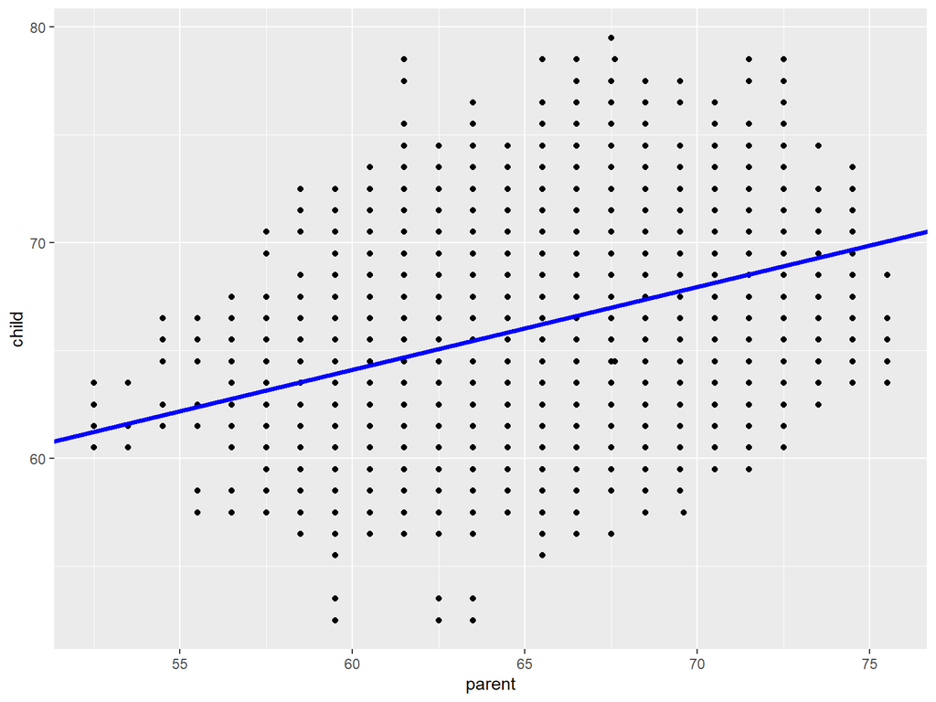

```r
ggplot(data = df, aes(x = parent, y = child)) +
    geom_point() +
    geom_abline(aes(intercept = a, slope = b),
                col = "blue", size = 1.5)
```

# Linear models in R

Actually, ggplot has this option!

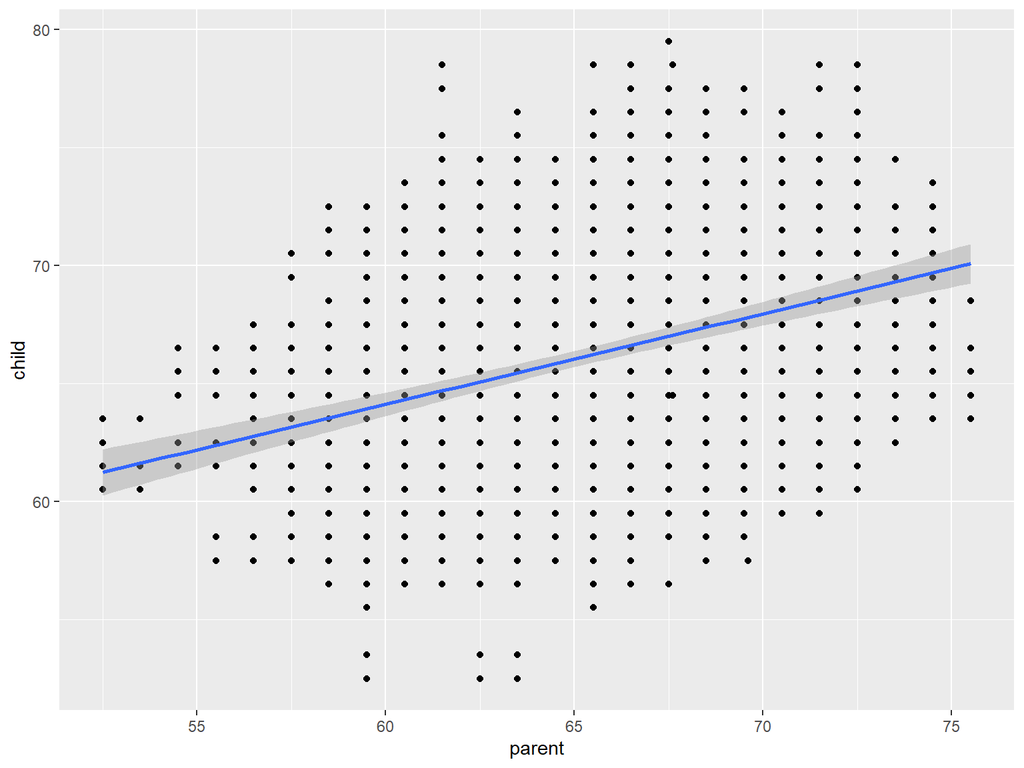

```r
ggplot(data = df, aes(x = parent, y = child)) +
    geom_point() +
    geom_smooth(method = "lm")
```

# Linear models in R

You can can fit linear model to different categories.

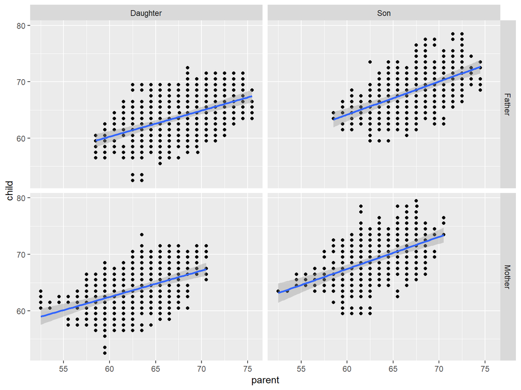

```r
ggplot(data = df, aes(x = parent, y = child)) +
geom_point() +
facet_grid(par~chl)+
geom_smooth(method = "lm")
```

# Prediction with regression

Suppose you know the parent’s height. You would like **to predict** how tall would be the child.

```r
new_parent_heights <- data.frame(parent = c(65, 60, 71))
new_df <- new_parent_heights %>% mutate(child = a + b * parent)
new_df
```

```
##   parent    child
## 1     65 66.04347
## 2     60 64.12236
## 3     71 68.34879
```

```r
predict(fit, newdata = new_parent_heights)
```

```
##        1        2        3
## 66.04347 64.12236 68.34879
```

# Prediction with regression

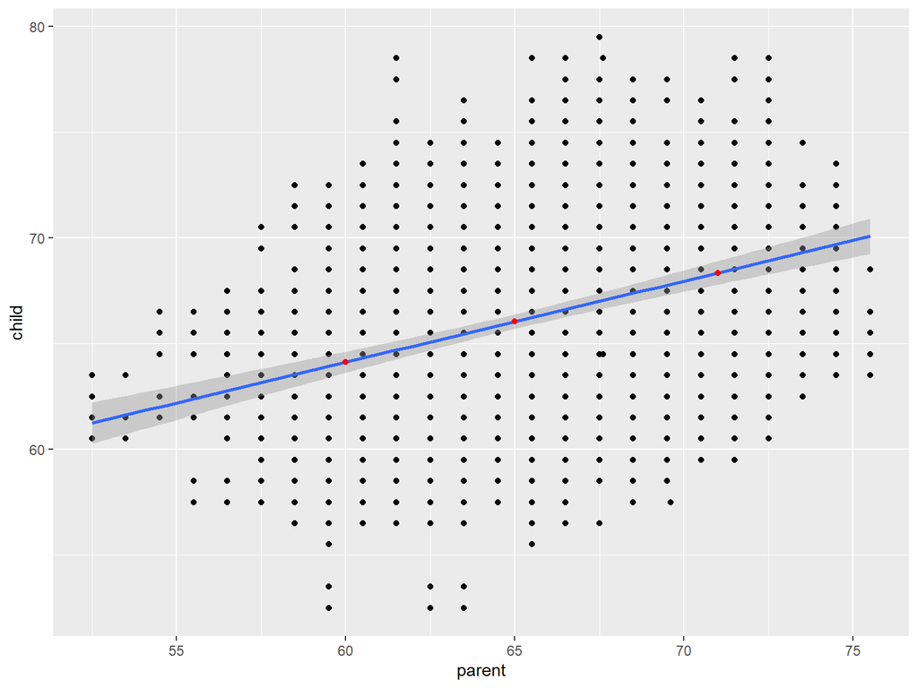

```r
ggplot(data = df, aes(x = parent, y = child)) +
    geom_point() +
    geom_smooth(method = "lm") +
    geom_point(data = new_df, aes(x = parent, y = child), color = "red")
```

# Today’s dataset: Top 100 songs on Spotify

[figure not shown]

(Source: [Spotify](https://open.spotify.com/playlist/37i9dQZF1DX7Axsg3uaDZb))

# Summary of the course

- Variable types
- Basic objects in R (vectors, lists, data frames)
- Plotting data with `ggplot2`
- Transforming and joining data with `dplyr` and `tidyr`
- Importing and exporting data
- R scripts and R markdown
- Making maps
- Basic statistical testing and modeling

# Where do we go from here?

- Statistical methods: STATS 60, STATS 101
- Read [R for Data Science](http://r4ds.had.co.nz/) from cover to cover!
- Go through the programming exercises and solutions
- Take short courses on [DataCamp](https://www.datacamp.com/onboarding/learn?from=home&technology=r)
- Writing your own functions and running simulations
- Interactive plots with `plotly`
- Advanced mapping with `ggmap`
- Predictive models/machine learning with `caret`
- Interactive web apps with `shiny`
- Text analysis with `tidytext`
  - Recommmended text: *Text Mining with R* by Julia Silge and David Robinson (avaible online for free at [tidytextmining.com](http://tidytextmining.com/))

# The end

[figure not shown]